# Statistics and Predictive Analytics, Lab 6

Your name here

Last lab!

In lecture we talked about ROC curves, class decision thresholds and introduced SVMs. This lab will give you practice working with those techniques. Here are the topics we will cover:

- Data exploration and cleaning.
- Probability and conditional probability of an event.
- Logistic regression models.
- KNN and SVM classification.
- Area under the curve (AUC).
- Using logistic regression to calculate change in the probability of an event.

Download the “adult” dataset from the folder for Lab 6 in Canvas. See the data dictionary: https://archive.ics.uci.edu/ml/datasets/adult and https://archive.ics.uci.edu/ml/machine-learning-databases/adult/adult.names. Income will be the outcome variable for the analyses using this dataset.

### Data Exploration and cleaning

Let’s start by doing some data exploration in order to assess what sort of cleaning needs to take place.

```r
a <- read.csv("adult.csv")[,-1]
glimpse(a)
```

```
Observations: 32,561
Variables: 13
$ age           <int> 39, 50, 38, 53, 28, 37, 49, 52, 31, 42, 37, 30, 23, 32, 40, 34, 25, 32, 38, 43,...
$ type_employer <fct> State-gov, Self-emp-not-inc, Private, Private, Private, Private, Private, Self-...
$ education_num <int> 13, 13, 9, 7, 13, 14, 5, 9, 14, 13, 10, 13, 13, 12, 11, 4, 9, 9, 7, 14, 16, 9, ...
$ marital       <fct> Never-married, Married-civ-spouse, Divorced, Married-civ-spouse, Married-civ-sp...
$ occupation    <fct> Adm-clerical, Exec-managerial, Handlers-cleaners, Handlers-cleaners, Prof-speci...
$ relationship  <fct> Not-in-family, Husband, Not-in-family, Husband, Wife, Wife, Not-in-family, Husb...
$ race          <fct> White, White, White, Black, Black, White, Black, White, White, White, Black, As...
$ sex           <fct> Male, Male, Male, Male, Female, Female, Female, Male, Female, Male, Male, Male,...
$ capital_gain  <int> 2174, 0, 0, 0, 0, 0, 0, 0, 14084, 5178, 0, 0, 0, 0, 0, 0, 0, 0, 0, 0, 0, 0, 0, ...
$ capital_loss  <int> 0, 0, 0, 0, 0, 0, 0, 0, 0, 0, 0, 0, 0, 0, 0, 0, 0, 0, 0, 0, 0, 0, 0, 2042, 0, 0...
$ hr_per_week   <int> 40, 13, 40, 40, 40, 40, 16, 45, 50, 40, 80, 40, 30, 50, 40, 45, 35, 40, 50, 45,...
$ country       <fct> United-States, United-States, United-States, United-States, Cuba, United-States...
$ income        <fct> <=50K, <=50K, <=50K, <=50K, <=50K, <=50K, <=50K, >50K, >50K, >50K, >50K, >50K, ...
```

The dataset has 13 variables and 32,561 observations, with many factor variables. We’ll look at a summary of the data to assess whether any cleaning is necessary.

```r
summary(a)
```

```
      age                 type_employer   education_num                    marital
 Min.   :17.00   Private         :22696   Min.   : 1.00   Divorced             : 4443
 1st Qu.:28.00   Self-emp-not-inc: 2541   1st Qu.: 9.00   Married-AF-spouse    :   23
 Median :37.00   Local-gov       : 2093   Median :10.00   Married-civ-spouse   :14976
 Mean   :38.58   ?               : 1836   Mean   :10.08   Married-spouse-absent:  418
 3rd Qu.:48.00   State-gov       : 1298   3rd Qu.:12.00   Never-married        :10683
 Max.   :90.00   Self-emp-inc    : 1116   Max.   :16.00   Separated            : 1025
                 (Other)         :  981                   Widowed              :  993
           occupation           relationship                   race           sex         capital_gain
 Prof-specialty :4140   Husband       :13193   Amer-Indian-Eskimo:  311   Female:10771   Min.   :    0
 Craft-repair   :4099   Not-in-family : 8305   Asian-Pac-Islander: 1039   Male  :21790   1st Qu.:    0
 Exec-managerial:4066   Other-relative:  981   Black             : 3124                  Median :    0
 Adm-clerical   :3770   Own-child     : 5068   Other             :  271                  Mean   : 1078
 Sales          :3650   Unmarried     : 3446   White             :27816                  3rd Qu.:    0
 Other-service  :3295   Wife          : 1568                                             Max.   :99999
 (Other)        :9541
  capital_loss     hr_per_week             country        income
 Min.   :   0.0   Min.   : 1.00   United-States:29170   <=50K:24720
 1st Qu.:   0.0   1st Qu.:40.00   Mexico       :  643   >50K : 7841
 Median :   0.0   Median :40.00   ?            :  583
 Mean   :  87.3   Mean   :40.44   Philippines  :  198
 3rd Qu.:   0.0   3rd Qu.:45.00   Germany      :  137
 Max.   :4356.0   Max.   :99.00   Canada       :  121
                                  (Other)      : 1709
```

The ranges of the numeric variables look reasonable, as do the counts of the categorical variables. Note that some variables contain missing observations denoted by a question mark (“?”). We could leave those unchanged for the analysis—the question mark would be treated as just another factor level—or we could impute those missing observations, provided that they do not simply indicate an “other” category, or we could remove them. We should inspect the missing observations to understand them better, but first need to figure out which variables have missing observations.

```r
# Create a new dataset for summarizing the missing variables
missings <- data.frame(variables = names(a), missings = NA)
# Double-check to make sure this worked
head(missings)
```

|  | variables | missings |
| --- | --- | --- |
| 1 | age | NA |
| 2 | type_employer | NA |
| 3 | education_num | NA |
| 4 | marital | NA |
| 5 | occupation | NA |
| 6 | relationship | NA |

```r
# Use a loop to fill the missings column with an indicator:
# 1 if any missings, 0 otherwise
for(i in 1:nrow(missings)){
  missings[i, 2] <- ifelse(any(a[,i]=="?"), 1, 0)
}
# Inspect the summary of missings
missings
```

| variables | missings |
| --- | --- |
| age | 0 |
| type_employer | 1 |
| education_num | 0 |
| marital | 0 |
| occupation | 1 |
| relationship | 0 |
| race | 0 |
| sex | 0 |
| capital_gain | 0 |
| capital_loss | 0 |

[output cut: 3 more lines]

Is there a structure to the missings? Basically, we want to see whether we can discern from the structure of the data how we might impute values for “?.”

1. Occupation

`r`r summary(a$occupation) # 1843 ?s

```
                ?      Adm-clerical      Armed-Forces      Craft-repair
             1843              3770                 9              4099
  Exec-managerial   Farming-fishing Handlers-cleaners Machine-op-inspct
             4066               994              1370              2002
    Other-service   Priv-house-serv    Prof-specialty   Protective-serv
             3295               149              4140               649
            Sales      Tech-support  Transport-moving
             3650               928              1597
```

`r`r # Select only rows where occupation == ?  
subset(a, occupation == ?) %>% head(20)

|  | age | type_employer | education_num | marital | occupation | relationship | race | sex | capital_gain | capital_loss | hr_per_week | country | income |
| --- | --- | --- | --- | --- | --- | --- | --- | --- | --- | --- | --- | --- | --- |
| 28 | 54 | ? | 10 | Married-civ-spouse | ? | Husband | Asian-Pac-Islander | Male | 0 | 0 | 60 | South | >50K |
| 62 | 32 | ? | 4 | Married-spouse-absent | ? | Not-in-family | White | Male | 0 | 0 | 40 | ? | <=50K |
| 70 | 25 | ? | 10 | Never-married | ? | Own-child | White | Male | 0 | 0 | 40 | United-States | <=50K |
| 78 | 67 | ? | 6 | Married-civ-spouse | ? | Husband | White | Male | 0 | 0 | 2 | United-States | <=50K |
| 107 | 17 | ? | 6 | Never-married | ? | Own-child | White | Female | 34095 | 0 | 32 | United-States | <=50K |
| 129 | 35 | ? | 9 | Married-civ-spouse | ? | Husband | White | Male | 0 | 0 | 40 | United-States | <=50K |
| 150 | 43 | ? | 10 | Divorced | ? | Not-in-family | White | Female | 0 | 0 | 40 | United-States | <=50K |
| 155 | 52 | ? | 9 | Divorced | ? | Not-in-family | White | Male | 0 | 0 | 45 | United-States | >50K |
| 161 | 68 | ? | 2 | Divorced | ? | Not-in-family | White | Female | 0 | 0 | 20 | United-States | <=50K |
| 188 | 53 | ? | 13 | Divorced | ? | Not-in-family | White | Female | 0 | 0 | 50 | United-States | <=50K |

[output cut: 10 more lines]

2. Type-employer

`r`r # Summarize summary(a$type_employer)

```
               ?      Federal-gov        Local-gov     Never-worked
            1836              960             2093                7
         Private     Self-emp-inc Self-emp-not-inc        State-gov
           22696             1116             2541             1298
     Without-pay
              14
```

No “other” category here either.

3. Country

`r`r # Summarize summary(a$country) # 583 ?s

```
                         ?                   Cambodia
                       583                         19
                    Canada                      China
                       121                         75
                  Columbia                       Cuba
                        59                         95
        Dominican-Republic                    Ecuador
                        70                         28
               El-Salvador                    England
                       106                         90
                    France                    Germany
                        29                        137
                    Greece                  Guatemala
                        29                         64
                     Haiti         Holand-Netherlands
                        44                          1
                  Honduras                       Hong
                        13                         20
                   Hungary                      India
                        13                        100
                      Iran                    Ireland
                        43                         24
                     Italy                    Jamaica
                        73                         81
                     Japan                       Laos
                        62                         18
                    Mexico                  Nicaragua
                       643                         34
Outlying-US(Guam-USVI-etc)                       Peru
                        14                         31
               Philippines                     Poland
                       198                         60
                  Portugal                Puerto-Rico
                        37                        114
                  Scotland                      South
                        12                         80
                    Taiwan                   Thailand
                        51                         18
           Trinadad&Tobago              United-States
                        19                      29170
                   Vietnam                 Yugoslavia
                        67                         16
```

`r`r # Select only country == ?  
subset(a, country == ?) %>% head(20)

|  | age | type_employer | education_num | marital | occupation | relationship | race | sex | capital_gain | capital_loss | hr_per_week | country | income |
| --- | --- | --- | --- | --- | --- | --- | --- | --- | --- | --- | --- | --- | --- |
| 15 | 40 | Private | 11 | Married-civ-spouse | Craft-repair | Husband | Asian-Pac-Islander | Male | 0 | 0 | 40 | ? | >50K |
| 39 | 31 | Private | 10 | Married-civ-spouse | Sales | Husband | White | Male | 0 | 0 | 38 | ? | >50K |
| 52 | 18 | Private | 9 | Never-married | Other-service | Own-child | White | Female | 0 | 0 | 30 | ? | <=50K |
| 62 | 32 | ? | 4 | Married-spouse-absent | ? | Not-in-family | White | Male | 0 | 0 | 40 | ? | <=50K |
| 94 | 30 | Private | 9 | Married-civ-spouse | Sales | Wife | Asian-Pac-Islander | Female | 0 | 1573 | 35 | ? | <=50K |
| 246 | 56 | Private | 9 | Married-civ-spouse | Adm-clerical | Husband | White | Male | 0 | 0 | 35 | ? | <=50K |
| 250 | 45 | Private | 9 | Married-civ-spouse | Adm-clerical | Husband | White | Male | 0 | 0 | 40 | ? | <=50K |
| 298 | 39 | ? | 14 | Married-civ-spouse | ? | Wife | Asian-Pac-Islander | Female | 3464 | 0 | 40 | ? | <=50K |
| 394 | 34 | State-gov | 13 | Married-civ-spouse | Exec-managerial | Husband | White | Male | 7688 | 0 | 45 | ? | >50K |
| 454 | 42 | Private | 12 | Married-civ-spouse | Exec-managerial | Husband | Black | Male | 0 | 0 | 40 | ? | >50K |

[output cut: 10 more lines]

The fact that `country` also has values of “?” suggests that “?” does not represent a general “other” category. Nor is there any discernible logical structure that would allow us to figure out what “?” represents. All three variables with missings are likely to be strong predictors of income—especially the occupation variables—so I think it makes sense to simply remove the rows with question marks, especially given the large number of rows without any missing observations. That way we’ll be working with a clean dataset. In perusing the papers cited in the data dictionary, furthermore, it appears that other researchers have done just that, stripping out the unknowns.

There are risks to this strategy, of course, because the data are most likely missing at random (MAR). One way to approach this issue is to conduct a rough sensitivity analysis in which you impute the values with “?,” conduct the analysis, and then compare the results with those from the analysis in which the missings have been deleted. Ideally, they are similar: you don’t want want your results to hinge on data modeling decisions. If they are not similar then you’ve got a problem. You’ll need to think harder about data modeling.

Do additional data exploration here:

`r`r # Your code goes here

### Probability

**Question 1**. Remove all the rows with question marks (you should have 30162 rows in the cleaned dataset) and calculate the probability, rounded to 2 decimals, of earning more than 50k in this dataset. In this case the probability is just the proportion of people earning more than 50k.

`r`r # Your code goes here # Here is the probabilty before cleaning, which is just the count # of incomes over 50k divided by the number of rows sum(a$income==>50K)/nrow(a)

```
[1] 0.2408096
```

`r`r # Cleaning. The following code uses a trick: turn the ?s into # NA then eliminate the NAs. a[a==?] <- NA a <- na.omit(a) # Check to see that the removal worked. This should produce # an empty dataset. subset(a, country==? | occupation == ? | type_employer == ?) r # Probability after cleaning sum(a$income==>50K)/nrow(a)

```
[1] 0.2489225
```

| age | type_employer | education_num | marital | occupation | relationship | race | sex | capital_gain | capital_loss | hr_per_week | country | income |
| --- | --- | --- | --- | --- | --- | --- | --- | --- | --- | --- | --- | --- |

> Your answer goes here

> .25 is the probability of earning more than 50k (after deleting the missing observations).

After removing the rows with “?” we need to refactor country, occupation and type_employer, otherwise R will retain the now empty category of “?” as the reference category.

`r`r a$country <- factor(a$country) a$occupation <- factor(a$occupation) a$type_employer <- factor(a$type_employer)

**Question 2**: Workers with occupation listed as “Exec-managerial” have the highest probability in this dataset of having an income greater than 50k. What is that probability (rounded to two decimals)?

`r`r # Write your code here # Two ways to calculate this #1. using a logistic model display(occ <- glm(income ~ occupation , data=a, family=binomial))

```
glm(formula = income ~ occupation, family = binomial, data = a)
                            coef.est coef.se
(Intercept)                 -1.87     0.05
occupationArmed-Forces      -0.21     1.06
occupationCraft-repair       0.63     0.06
occupationExec-managerial    1.81     0.06
occupationFarming-fishing   -0.16     0.11
occupationHandlers-cleaners -0.86     0.12
occupationMachine-op-inspct -0.08     0.08
occupationOther-service     -1.28     0.10
occupationPriv-house-serv   -3.09     1.00
occupationProf-specialty     1.66     0.06
occupationProtective-serv    1.14     0.10
occupationSales              0.88     0.06
occupationTech-support       1.04     0.09
occupationTransport-moving   0.50     0.08
---
  n = 30162, k = 14
  residual deviance = 29953.9, null deviance = 33850.7 (difference = 3896.8)
```

`r`r invlogit(coef(occ)[1] + coef(occ)[4])

```
(Intercept)
  0.4852204
```

`r`r # Using dplyr a %>% group_by(occupation) %>% summarize(prob = sum(income==>50K)/length(income)) %>% filter(occupation == -managerial)

| occupation | prob |
| --- | --- |
| Exec-managerial | 0.4852204 |

> Your answer goes here.

> Exec-managerial has a .49 probability of making more than 50k. Note that this is a conditional probability, while the first question asks for an unconditional probability. In the case of conditional probability we want to know the occurrence of the event given a condition. If we want to know the probability that a dog will live to age 15 then the (theoretical) calculation would be: (number surviving to age 15)/ (number of dogs). If we want to know the conditional probability of surviving to age 15 given that a dog weighs more than 50 pounds, then the calculation would be: (number of dogs heavier than 50 pounds surviving to age 15)/ (number of dogs heavier than 50 pounds).

**Question 3**: Which occupation has the *lowest* probability of having an income greater than 50k?

`r`r a %>% group_by(occupation) %>% summarize(prob = sum(income==>50K)/length(income)) %>% filter(prob== min(prob))

| occupation | prob |
| --- | --- |
| Priv-house-serv | 0.006993007 |

> Your answer goes here.

> Priv-house-serv has the lowest probability of making greater than 50k.

### Logistic regression

Next we will fit a sequence of models of income using caret and its default bootstrap cross-validation. Make sure to set the seed as indicated, and to center and scale where appropriate. These are computationally expensive operations so, to speed model fitting, we will prepare a random subset of the data (2000 rows). Allow caret’s default settings to pick optimal values for user-specified parameters.

`r`r set.seed(38) a_sub <- sample_n(a, 2000) summary(a_sub)

```
      age                type_employer  education_num
 Min.   :17.0   Federal-gov     :  65   Min.   : 1.00
 1st Qu.:28.0   Local-gov       : 131   1st Qu.: 9.00
 Median :37.0   Private         :1474   Median :10.00
 Mean   :38.3   Self-emp-inc    :  82   Mean   :10.19
 3rd Qu.:47.0   Self-emp-not-inc: 177   3rd Qu.:13.00
 Max.   :90.0   State-gov       :  70   Max.   :16.00
                Without-pay     :   1
                  marital              occupation          relationship
 Divorced             :276   Craft-repair   :300   Husband       :850
 Married-AF-spouse    :  2   Prof-specialty :264   Not-in-family :484
 Married-civ-spouse   :941   Exec-managerial:256   Other-relative: 69
 Married-spouse-absent: 28   Adm-clerical   :239   Own-child     :302
 Never-married        :635   Sales          :239   Unmarried     :216
 Separated            : 62   Other-service  :206   Wife          : 79
 Widowed              : 56   (Other)        :496
                 race          sex        capital_gain
 Amer-Indian-Eskimo:  19   Female: 624   Min.   :    0
 Asian-Pac-Islander:  56   Male  :1376   1st Qu.:    0
 Black             : 175                 Median :    0
 Other             :  21                 Mean   : 1204
 White             :1729                 3rd Qu.:    0
                                         Max.   :99999

  capital_loss      hr_per_week             country       income
 Min.   :   0.00   Min.   : 2.00   United-States:1833   <=50K:1500
 1st Qu.:   0.00   1st Qu.:40.00   Mexico       :  41   >50K : 500
 Median :   0.00   Median :40.00   Philippines  :  12
 Mean   :  87.32   Mean   :40.98   Jamaica      :  10
 3rd Qu.:   0.00   3rd Qu.:45.00   Germany      :   9
 Max.   :4356.00   Max.   :99.00   Puerto-Rico  :   9
                                   (Other)      :  86
```

**Question 4**: Fit a logistic model of income, using all the predictors. Report caret’s cross-validation estimate of out-of-sample accuracy for this model. In caret, the method argument for logistic regression is “glm.” Remember to use the subsetted data in the data argument.

`r`r # Your code goes here set.seed(38) glm_model <- train(income ~., data = a_sub, method = ) glm_model

```
Generalized Linear Model

2000 samples
  12 predictor
   2 classes: '<=50K', '>50K'

No pre-processing
Resampling: Bootstrapped (25 reps)
Summary of sample sizes: 2000, 2000, 2000, 2000, 2000, 2000, ...
Resampling results:

  Accuracy   Kappa
  0.8358705  0.5212161
```

`r`r summary(glm_model)

```
Call:
NULL

Deviance Residuals:
    Min       1Q   Median       3Q      Max
-2.3922  -0.4932  -0.1760   0.0000   3.1974

Coefficients: (4 not defined because of singularities)
                                      Estimate Std. Error z value
(Intercept)                         -2.546e+01  3.956e+03  -0.006
age                                  3.454e-02  7.019e-03   4.921
`type_employerLocal-gov`            -3.331e-01  4.716e-01  -0.706
type_employerPrivate                -1.977e-01  3.859e-01  -0.512
`type_employerSelf-emp-inc`         -2.756e-01  4.895e-01  -0.563
`type_employerSelf-emp-not-inc`     -7.121e-01  4.433e-01  -1.606
`type_employerState-gov`            -3.965e-01  5.158e-01  -0.769
`type_employerWithout-pay`          -1.288e+01  3.956e+03  -0.003
education_num                        3.420e-01  3.961e-02   8.635
`maritalMarried-AF-spouse`          -1.739e+01  2.753e+03  -0.006
`maritalMarried-civ-spouse`         -1.958e-01  1.556e+00  -0.126
`maritalMarried-spouse-absent`      -1.817e-01  1.210e+00  -0.150
`maritalNever-married`              -3.716e-01  3.581e-01  -1.038
maritalSeparated                     2.426e-02  5.835e-01   0.042
maritalWidowed                      -9.019e-02  6.778e-01  -0.133
`occupationArmed-Forces`            -1.457e+01  3.956e+03  -0.004
`occupationCraft-repair`             1.010e-01  3.144e-01   0.321
`occupationExec-managerial`          6.272e-01  3.201e-01   1.959
`occupationFarming-fishing`         -1.827e+00  6.416e-01  -2.848
`occupationHandlers-cleaners`       -8.214e-01  6.594e-01  -1.246
`occupationMachine-op-inspct`       -2.083e-01  4.061e-01  -0.513
`occupationOther-service`           -7.446e-01  4.859e-01  -1.533
`occupationPriv-house-serv`         -1.396e+01  1.557e+03  -0.009
`occupationProf-specialty`           2.260e-01  3.328e-01   0.679
`occupationProtective-serv`          1.951e-01  5.310e-01   0.367
occupationSales                      1.605e-01  3.383e-01   0.474
`occupationTech-support`             7.039e-01  4.198e-01   1.677
`occupationTransport-moving`        -1.538e-01  3.949e-01  -0.389
`relationshipNot-in-family`         -1.935e+00  1.550e+00  -1.249
`relationshipOther-relative`        -1.576e+00  1.406e+00  -1.121
`relationshipOwn-child`             -3.659e+00  1.642e+00  -2.229
```

[output cut: 127 more lines]

```
countryThailand                     0.999679
`countryTrinadad&Tobago`            0.999319
`countryUnited-States`              0.996463
countryVietnam                      0.999928
countryYugoslavia                         NA
---
Signif. codes:  0 ‘***’ 0.001 ‘**’ 0.01 ‘*’ 0.05 ‘.’ 0.1 ‘ ’ 1

(Dispersion parameter for binomial family taken to be 1)

    Null deviance: 2249.3  on 1999  degrees of freedom
Residual deviance: 1243.8  on 1923  degrees of freedom
AIC: 1397.8

Number of Fisher Scoring iterations: 16
```

> Your answer goes here.

> The estimated out-of-sample accuracy was about .84

**Question 5**: Fit a glmnet model of income, using all the predictors. Glmnet works fine for classification. Report caret’s cross-validation estimate of out-of-sample accuracy for this model.

`r`r # Your code goes here set.seed(38) glmnet_model <- train(income ~., data = a_sub, preProcess = c(,), method=) glmnet_model

```
glmnet

2000 samples
  12 predictor
   2 classes: '<=50K', '>50K'

Pre-processing: centered (80), scaled (80)
Resampling: Bootstrapped (25 reps)
Summary of sample sizes: 2000, 2000, 2000, 2000, 2000, 2000, ...
Resampling results across tuning parameters:

  alpha  lambda        Accuracy   Kappa
  0.10   0.0003781588  0.8462217  0.5656350
  0.10   0.0037815876  0.8470211  0.5648957
  0.10   0.0378158759  0.8400060  0.5214762
  0.55   0.0003781588  0.8469741  0.5676099
  0.55   0.0037815876  0.8482120  0.5669790
  0.55   0.0378158759  0.8347601  0.4879867
  1.00   0.0003781588  0.8465995  0.5662269
  1.00   0.0037815876  0.8496796  0.5691065
  1.00   0.0378158759  0.8255543  0.4537840

Accuracy was used to select the optimal model using the largest value.
The final values used for the model were alpha = 1 and lambda
 = 0.003781588.
```

You can look at the model coefficients with this code (replacing “glmnet_model” with your own model name):

`r`r coef(glmnet_model$finalModel, glmnet_model$finalModel$tuneValue$lambda) %>% round(2)

```
81 x 1 sparse Matrix of class \dgCMatrix\
                                      1
(Intercept)                       -1.81
age                                0.39
type_employerLocal-gov             .
type_employerPrivate               .
type_employerSelf-emp-inc          .
type_employerSelf-emp-not-inc     -0.11
type_employerState-gov             0.00
type_employerWithout-pay           .
education_num                      0.83
maritalMarried-AF-spouse           0.00
maritalMarried-civ-spouse          0.82
maritalMarried-spouse-absent       .
maritalNever-married              -0.12
maritalSeparated                   .
maritalWidowed                     .
occupationArmed-Forces             .
occupationCraft-repair             .
occupationExec-managerial          0.15
occupationFarming-fishing         -0.25
occupationHandlers-cleaners       -0.07
occupationMachine-op-inspct       -0.03
occupationOther-service           -0.16
occupationPriv-house-serv          .
occupationProf-specialty           0.01
occupationProtective-serv          .
occupationSales                    0.00
occupationTech-support             0.08
occupationTransport-moving        -0.01
relationshipNot-in-family         -0.01
relationshipOther-relative         .
relationshipOwn-child             -0.43
relationshipUnmarried              .
relationshipWife                   0.11
raceAsian-Pac-Islander             0.03
raceBlack                          .
raceOther                          .
raceWhite                          .
sexMale                            0.35
```

[output cut: 28 more lines]

```
countryNicaragua                   .
countryOutlying-US(Guam-USVI-etc)  .
countryPeru                        .
countryPhilippines                -0.11
countryPoland                      .
countryPortugal                    .
countryPuerto-Rico                -0.01
countryScotland                    .
countrySouth                       .
countryTaiwan                      .
countryThailand                    .
countryTrinadad&Tobago             .
countryUnited-States               0.17
countryVietnam                    -0.02
countryYugoslavia                  .
```

> Your answer goes here.

> The accuracy is about .85, so not really any improvement. This is a little surprising since with all of the categorical variables there are actually lots of potential parameters in the model, and thus many opportunities for glmnet, having chosen a model with alpha = 1 (i.e., a lasso model), to remove predictors from the model. It did, in fact, remove many parameters. Even if this model is not more accurate than the logistic model, then, it is simpler, which makes it preferable.

### Classification with KNN and SVM

**Question 6**: Fit a KNN model of income, using all the predictors. Report caret’s cross-validation estimate of out-of-sample accuracy for this model.

`r`r # Your code goes here set.seed(38) knn_model <- train(income ~., data = a_sub, preProcess = c(,), method=) knn_model

```
k-Nearest Neighbors

2000 samples
  12 predictor
   2 classes: '<=50K', '>50K'

Pre-processing: centered (80), scaled (80)
Resampling: Bootstrapped (25 reps)
Summary of sample sizes: 2000, 2000, 2000, 2000, 2000, 2000, ...
Resampling results across tuning parameters:

  k  Accuracy   Kappa
  5  0.7786891  0.3887165
  7  0.7876786  0.4028774
  9  0.7929420  0.4113164

Accuracy was used to select the optimal model using the largest value.
The final value used for the model was k = 9.
```

> Your answer goes here.

> The accuracy was about .79.

**Question 7**: Fit a linear support vector machine (SVM) model of income, using all the predictors. Report caret’s cross-validation estimate of out-of-sample accuracy for this model. Set the method argument to “svmLinear2.”

`r`r # Your code goes here set.seed(38) svm_model <- train(income ~., data = a_sub, preProcess = c(,), method=2) svm_model

```
Support Vector Machines with Linear Kernel

2000 samples
  12 predictor
   2 classes: '<=50K', '>50K'

Pre-processing: centered (80), scaled (80)
Resampling: Bootstrapped (25 reps)
Summary of sample sizes: 2000, 2000, 2000, 2000, 2000, 2000, ...
Resampling results across tuning parameters:

  cost  Accuracy   Kappa
  0.25  0.8491953  0.5729761
  0.50  0.8488684  0.5723984
  1.00  0.8482866  0.5711342

Accuracy was used to select the optimal model using the largest value.
The final value used for the model was cost = 0.25.
```

> Your answer goes here.

> The accuracy was about .85, so very similar to the logistic regressions.

The Lasso model had the best performance, given this seed, just *barely* beating out SVM. Additionally, Lasso has a big advantage in that it is easy to extract probabilities from it, whereas for machine learning models such as SVM (and KNN) probabilities must be reverse engineered (given the way those algorithms work).

### AUC

**Question 8**: Calculate AUC for the glmnet model, using the entire dataset in the arguments to the `roc` function.

`r`r library(pROC) roc(a$income, predict(glmnet_model, newdata = a, type = )[,2], plot=T)

```
Call:
roc.default(response = a$income, predictor = predict(glmnet_model,     newdata = a, type = \prob\)[, 2], plot = T)

Data: predict(glmnet_model, newdata = a, type = \prob\)[, 2] in 22654 controls (a$income <=50K) < 7508 cases (a$income >50K).
Area under the curve: 0.8995
```

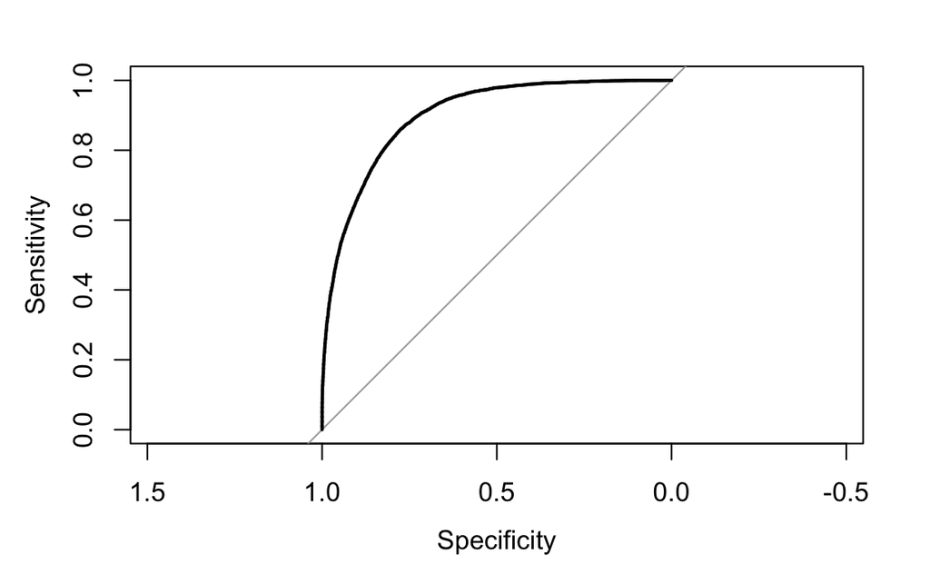

> Your answer goes here.

> AUC for the lasso model is .8995. The advantage of using AUC as a performance metric for comparing models is that it uses information from the confusion matrix and therefore is not tied to a particular model type, like deviance or AIC, which both use log likelihoods from parametric statistical models.

### Calculating change in probability

We can use the lasso model to calculate the probability of having income greater than 50k income. Remember that the inputs to this model are (or should be) centered. So the the intercept, for example, represents the average (or reference case) log odds of greater than 50k earnings: -1.81.

**Question 9**: Using the glmnet model, calculate the change in probability of earning more than 50k change for someone who is 30 years old vs 50 years old with the following characteristics: - type_employer = Private - education_num = 12 - marital = Married-civ-spouse - occupation = Prof-specialty - relationship = Husband - race = White - sex = Male - capital_gain = 0 - capital_loss = 0 - hr_per_week = 40 - country = United-States

`r`r # Your code goes here df <- data.frame(age = c(30,50), type_employer = , education_num = 12, marital = -civ-spouse, occupation = -specialty, relationship = , race = , sex = , capital_gain = 0, capital_loss = 0, hr_per_week = 40, country = -States) df r predict(glmnet_model, newdata= df, type = )[2,2] - predict(glmnet_model, newdata= df, type = )[1,2]

```
[1] 0.1478464
```

| age | type_employer | education_num | marital | occupation | relationship | race | sex | capital_gain | capital_loss | hr_per_week | country |
| --- | --- | --- | --- | --- | --- | --- | --- | --- | --- | --- | --- |
| 30 | Private | 12 | Married-civ-spouse | Prof-specialty | Husband | White | Male | 0 | 0 | 40 | United-States |
| 50 | Private | 12 | Married-civ-spouse | Prof-specialty | Husband | White | Male | 0 | 0 | 40 | United-States |

> Your answer goes here

> The change in probability is .15.

**Question 10 (optional)**: A change of pace. Download the Pima dataset.

`r`r data(.te) data(.tr) pima <- rbind(Pima.te, Pima.tr)

Fit a model that predicts type using npreg, ped, glu, bmi, age and an interaction between npreg and ped (df = 525).

`r`r summary(m <- glm(type ~ npreg *ped+ glu +  
bmi + age , data=pima, family=binomial))

```
Call:
glm(formula = type ~ npreg * ped + glu + bmi + age, family = binomial,
    data = pima)

Deviance Residuals:
    Min       1Q   Median       3Q      Max
-3.0228  -0.6528  -0.3732   0.6244   2.5347

Coefficients:
             Estimate Std. Error z value Pr(>|z|)
(Intercept) -9.719729   0.930162 -10.449  < 2e-16 ***
npreg        0.076833   0.067915   1.131   0.2579
ped          0.978911   0.519963   1.883   0.0597 .
glu          0.035014   0.004206   8.326  < 2e-16 ***
bmi          0.085785   0.018195   4.715 2.42e-06 ***
age          0.023521   0.013316   1.766   0.0773 .
npreg:ped    0.098263   0.110408   0.890   0.3735
---
Signif. codes:  0 ‘***’ 0.001 ‘**’ 0.01 ‘*’ 0.05 ‘.’ 0.1 ‘ ’ 1

(Dispersion parameter for binomial family taken to be 1)

    Null deviance: 676.79  on 531  degrees of freedom
Residual deviance: 466.28  on 525  degrees of freedom
AIC: 480.28

Number of Fisher Scoring iterations: 5
```

Suppose that a non-profit health organization wanted to use your model to predict diabetes in this population, but they wanted to do so very conservatively. That is, they aren’t worried about **over**predicting diabetes. (At the worst, they reason, it would be an inconvenience for patients to come in to get tested.) Instead, they want to avoid **under**predicting diabetes. Specifically, they would like to push the number of false negatives (instances where the model predicts incorrectly that a person does not have diabetes) down to no more than 2% of the population. That is, if the population were 1000, they would want there to be no more than 20 false negatives. Which class decision threshold would achieve this objective?

`r`r round(nrow(pima)*.02)

```
[1] 11
```

`r`r preds <- ifelse(predict(m, newdata=pima, type=) > .14, , ) confusionMatrix(preds, pima$type)$table

```
          Reference
Prediction  No Yes
       No  185   9
       Yes 170 168
```

`r`r preds <- ifelse(predict(m, newdata=pima, type=) > .15, , ) confusionMatrix(preds, pima$type)$table

```
          Reference
Prediction  No Yes
       No  192  10
       Yes 163 167
```

`r`r preds <- ifelse(predict(m, newdata=pima, type=) > .16, , ) confusionMatrix(preds, pima$type)$table

```
          Reference
Prediction  No Yes
       No  197  12
       Yes 158 165
```

> Your answer goes here

> The way to approach this question is to play around with the threshold for converting probabilities into predictions on the scale of the outcome. We need to have false negatives (in the upper right cell of the above confusion matrix) down around 11, given that 2% of the train set is 10.6. This is accomplished with a decision or discrimination threshold of .15. In other words, we want to decrease the decision threshold so we overpredict diabetes and have fewer false negatives.

**Question 11**: Please score yourself on this lab using the answer key. For each question, reflect on the difficulty of the question for you and whether you:

- Did not try (just copied the answer key or left it blank).
- Looked at the answer key to get a hint.
- Tried but got the wrong answer.
- Tried and got the right answer.

> Write your answers here.

**Next step.** After you’ve finished this lab, go take Quiz 6. You have one try at the quiz, limited to 30 minutes. There are five multiple choice and multiple answer questions focusing on the material from this lab.